# Introduction to rivSurveyR

### Estimating shear velocity

If the sediment diameter of the 90th percentile and n for the study area are known, the shear velocity can be estimated. Here Dc is set to 0.0375m to represent a river bed of hard-pan clay covered with zebra mussels and velocity vectors from the last measured cell are used to calculate shear velocity.

```r
shearVelocity <- shearVel(mean.planform.meter$BC.Vel.E, mean.planform.meter$BC.Vel.N,
                          mean.planform.meter$BC.Vel.Up, mean.planform.meter$depth,
                          mean.planform.meter$bottomCellDepth, Dc=0.0375, n=2, p=1000,
                          reference="bottomCell", units="metric")
shearVelocity
```

```
##            ustarE       ustarN      ustar ustarHeading
##    1:  0.04007887 -0.033856554 0.05251445    130.18939
##    2:  0.03375578 -0.035005989 0.04872162    136.04163
##    3:  0.02594672 -0.029411381 0.03930087    138.58126
##    4:  0.03281196 -0.038692766 0.05074006    139.70163
##    5:  0.02059405 -0.025753070 0.03307510    141.35160
##   ---
## 2010: -0.01777415 -0.020271340 0.02696089    221.24466
## 2011:  0.01816185 -0.010454139 0.02749996    119.92515
## 2012:  0.01951470  0.021355706 0.03303732     42.42085
## 2013:  0.03508477 -0.009796942 0.03881256    105.60166
## 2014:  0.02901785  0.016967382 0.03591764     59.68423
```

```r
#Append to mean.planform
mean.planform.meter <- cbind(mean.planform.meter, shearVelocity)
```

### Spatial averaging and standard deviation

Once the data has been summarized, it can be spatially averaged with `spatialAverage`, which uses a moving window of x and y (if twoD=TRUE) neighbors to average the each variable. To average the `mean.planform` dataset, define the number of units of the moving window in the horizontal direction (i.e., `xWindow`), define the coordinates used to project the data in space (i.e., `spatialCoords`), and the `groups` used to separate the transects. Here the `xWindow=20`, the `spatialCoords="tDist"` (the distance along a transect), and setting `groups="transectName"` ensures each transect is spatially averaged separately. Since averaging will be conducted along individual transects, `twoD=FALSE`, the default.

```r
spatialMean.planform <- spatialAverage(mean.planform.meter, xWindow=20, spatialCoords="tDist",
                                       groups="transectName")
```

```
## Spatial Averaging in Process, Please Be Patient
```

```
## One Dimensional Spatial Averaging Complete
```

```
## Window Size: 20 cells
```

```r
dim(spatialMean.planform)
```

```
## [1] 2014   33
```

```r
dim(mean.planform.meter)
```

```
## [1] 2014   33
```

Similarly, `spatialSD` can be used to calculate the spatial standard deviation

```r
spatialSD.planform <- spatialSD(mean.planform.meter, xWindow=20, spatialCoords=c("tDist"),
                                groups=c("transectName"))
```

```
## Spatial Standard Deviation Being Calculated, Please Be Patient
```

```
## One Dimensional Standard Deviation Calculated
```

```
## Window Size: 20 cells
```

```r
dim(spatialSD.planform)
```

```
## [1] 2014   33
```

```r
dim(mean.planform.meter)
```

```
## [1] 2014   33
```

The plots below show depth averaged water speeds before and after spatial averaging.

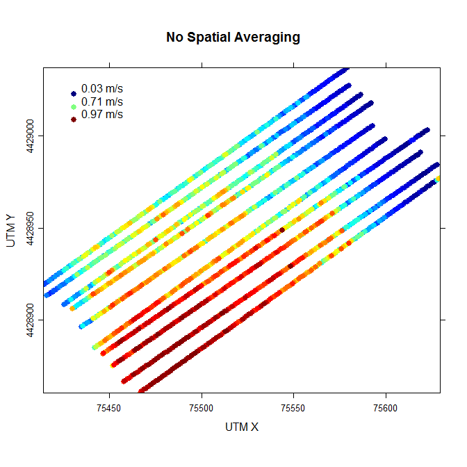

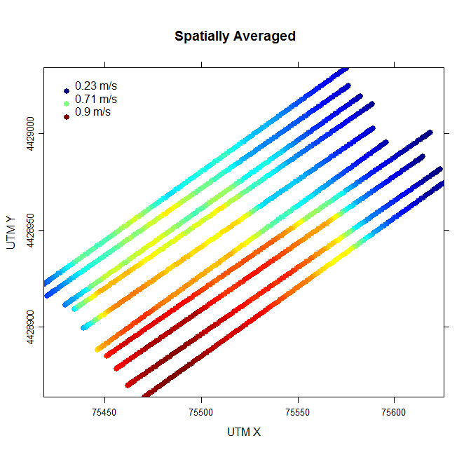

## Processing SonTek ADCP cross-section data step-by-step

### Compiling SonTek ADCP cross-section data

Cross-sections of transects can also be processed following a procedure similar to the one used to process the planform data. The data that was imported into R in the “Compiling SonTek ADCP planform data” section can be used for these steps. Similar to `xSec.planform`, `xSec.secondary` takes a list of files exported from RiverSurveyor Live as MATLAB files and a character list containing the transect name each file represents and compiles the flow data for each cell within an ensemble. This can result in large datasets and the input files for this example are trimmed for the sake of speed.

```r
mNineTrim <- mNine[1:6]
tNamesTrim <- tNames[1:6]
```

Next supply the trimmed lists to `xSec.secondary`.

```r
secondary <- xSec.secondary(data=mNineTrim, transectNames=tNamesTrim)
```

### Averaging cross-section data from SonTek ADCP measurements

The flow data can now be summarized using `average.secondary`, this function takes ADCP data and applies a function summarizing overlapping cells, similar to `average.planform`.

```r
mean.secondary <- average.secondary(secondary)
nrow(secondary)
```

```
## [1] 44386
```

```r
nrow(mean.secondary)
```

```
## [1] 26383
```

In addition to providing the mean for each set of replicates (from replicate transects), the transect heading, distance each sample is from the start of the transect (transects are assumed to start river right), cell width, water speed within a cell, the compass heading of flow within a cell, and altitude of a cell are calculated.

As with `average.planform` the list of transects imported into R and the list containing names of those transects can be passed directly to `average.secondary`.

```r
mean.secondary.alt <- average.secondary(mNineTrim, tNamesTrim)
all.equal(mean.secondary, mean.secondary.alt)
```

```
## [1] TRUE
```

Lastly, the bin sizes used to group samples for summarization can be defined with `binWidth` (see “Averaging planform data from SonTek ADCP measurements” for details) and `binHeight`. `binHeight` controls the cell height used to group samples for summarization, which defaults to the mean cell height if this argument is not supplied.

```r
mean.secondary.meterXHalfMeter <- average.secondary(mNineTrim, tNamesTrim, binWidth=1,
                                                    binHeight=0.5)
nrow(mean.secondary.meterXHalfMeter)
```

```
## [1] 9556
```

```r
nrow(mean.secondary)
```

```
## [1] 26383
```

### Rotations: Primary and secondary velocities

Water velocities measured by the ADCP are recorded as the magnitude to the east, north, and up (when using the ENU coordinate system). This references flow in geographic space, but provides little bearing on flow directions relative to the cross-section measured. Three rotation methods are available in `rivSurveyR` that calculate velocity parallel and perpendicular to the cross-section and primary and secondary velocities.

#### Calculate cross-section velocities parallel and perpendicular to the cross-section

The first method (`xSec`) calculates the velocity vectors that are parallel and perpendicular to a cross-section. To begin supply `xSec` with velocities in the East, north, and up directions and the heading of a transect. `xSec`, `zeroSecQ`, and `rozovskii` assume all velocities correspond to the same transect and it is important that the data passed to `xSec`, `zeroSecQ`, and `rozovskii` is subset to contain only the transect of interest.

```r
tThree.secondary <- mean.secondary.meterXHalfMeter[transectName=="t3",,]
xSec.tThree <- xSec(tThree.secondary$Vel.E, tThree.secondary$Vel.N, tThree.secondary$Vel.up,
                  mean(tThree.secondary$transectHeading, na.rm=TRUE))
#Add the cross-section velocities to the data set
tThree.secondary <- data.table(tThree.secondary, xSec.tThree)
```

This can be tedious if multiple transects need to be processed. Fortunately, other methods are available to process multiple transects at once, which are discussed in the “Process SonTek ADCP cross-section data” section.

#### Calculate primary and secondary velocities using the zero secondary discharge method of rotation

The second rotation method (`zeroSecQ`) uses the zero secondary discharge method of rotation to calculate primary and secondary velocities (see Lane et al. 2000 for details). `zeroSecQ` has the same data requirements as `xSec`, with the addition of the height and width of each cell sampled.

```r
zsq.tThree <- zeroSecQ(tThree.secondary$Vel.E, tThree.secondary$Vel.N, tThree.secondary$Vel.up,
                     tThree.secondary$cellHeight, tThree.secondary$cellWidth,
                     mean(tThree.secondary$transectHeading, na.rm=TRUE))
tThree.secondary <- data.table(tThree.secondary, zsq.tThree)
```

#### Calculate primary and secondary velocities using the Rozovskii method of rotation

Primary and secondary velocities are calculated using the Rozovskii method of rotation (Rhoads and Kenworthy 1998) in the third rotation method available (`rozovskii`). `rozovskii` requires velocities in the East, north, and up directions and East and North depth averaged velocities for each ensemble. As with the other methods of rotation, `rozovskii` assumes all data were measured along the same transect.

```r
roz.tThree <- rozovskii(tThree.secondary$Vel.E, tThree.secondary$Vel.N, tThree.secondary$Vel.up,
                      tThree.secondary$Mean.Vel.E, tThree.secondary$Mean.Vel.N)
tThree.secondary <- data.table(tThree.secondary, roz.tThree)
```

The plots below show the water velocity with and without rotation.

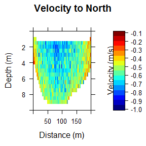

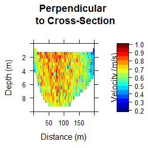

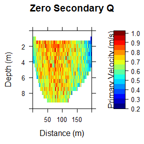

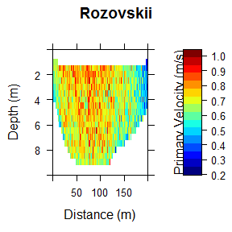

### Spatial averaging of cross-section velocities

The cross section data is still contains variation due to turbulence (Szupiany et al. 2007; Czuba et al. 2011), to better represent mean flows, spatial averaging can be conducted. The procedure follows as above, with a few differences. Because spatial averaging will be conducted by the distance along the transect, as well as by depth, `twoD=TRUE` and the number of units of the vertical moving window is supplied to `yWindow`. Additionally, “tDist” and “cellDepth” is passed to the `spatialCoords` argument, telling the moving window to move along each transect vertically by depth as well as horizontally by distance along the transect.

```r
spatialMean.secondary <- spatialAverage(tThree.secondary, xWindow=20, yWindow=9,
                                       spatialCoords=c("tDist", "cellDepth"),
                                       groups=c("transectName"))
```

```
## Spatial Averaging in Process, Please Be Patient
```

```
## Two Dimensional Spatial Averaging Complete
```

```
## Window Size: 20x9 cells
```

```r
dim(spatialMean.secondary)
```

```
## [1] 3198   54
```

```r
dim(tThree.secondary)
```

```
## [1] 3198   54
```

The figures below show the rotations after spatial averaging

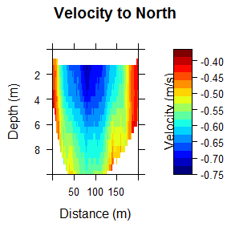

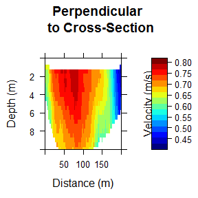

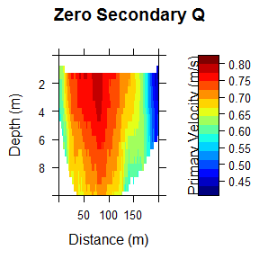

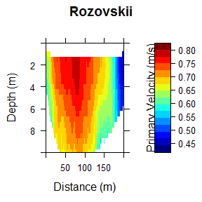

## Quickly process SonTek ADCP planform data

The previous sections provide a detailed example of the processing procedure and overview the functions used at each step. Although those functions can be used individually to process the ADCP data, `rivSurveyR` contains two functions which automate the steps used to process planform and cross-section data (`process.planform` and `process.secondary`). Planform data can easily be processed in one step with `process.planform`, which compiles the functions used in the “Processing SonTek ADCP planform data step-by-step” section. `process.planform` inherits all the arguments of those functions and provides some defaults to assist with processing. A list of transect files to process is the minimum that needs to be passed to `process.planform`. This runs the function with all the defaults and assumes transects are not replicated (i.e., all files are from individual transects). The default is to compute the layer averaged velocity using the entire measured water column, project the mean values of overlapping samples to the projected transect line, and spatial averaging is not conducted. Additionally, because the default omits Dc and n, shear velocities are not calculated.

```r
planform.ADCP.basic <- process.planform(mNine)
```

If something other than the default is desired, data processing can be customized by specifying the arguments passed to `process.planform`. The code below produces the same output that was produced in the “Processing SonTek ADCP planform data step-by-step” section.

```r
planform.ADCP <- process.planform(mNine, tNames, depthReference="VB",
                                  layerReference="bottom", x1=1, x2="minimum",
                                  binWidth=1, Dc=0.0375, n=2, xWindow=20)
```

```
## Compiling and Averaging Data
```

```
## Calculating Bottom Velocities
```

```
## Spatial Averaging in Process, Please Be Patient
```

```
## One Dimensional Spatial Averaging Complete
```

```
## Window Size: 20 cells
```

```r
all.equal(spatialMean.planform, planform.ADCP)
```

```
## [1] TRUE
```

Additionally, to avoid confusing results shear velocity and spatial averaging are only conducted if `FUN=mean`.

## Quickly process SonTek ADCP cross-section data

Similar to `process.planform`, `process.secondary` can be used to easily process cross-section velocities. At the minimum, only a list of transect files needs to be passed to `process.secondary`. If only a list of transect files are supplied, `process.secondary` is run with all the defaults, which are to project mean values of overlapping samples to a mean transect line, use mean cell height and horizontal distance between samples as binHeight and binWidth (respectively), calculate velocities orthogonal to the mean transect line, and spatial averaging is not conducted. Also, similar to `process.planform`, velocity rotations and spatial averaging are only conducted if `FUN=mean`. The example below yields the same output as the example in the “Processing SonTek ADCP cross-section data step-by-step” section.

```r
secondary.ADCP <- process.secondary(mNineTrim, tNamesTrim, binWidth=1, binHeight=0.5,
                                    rotation = c("xSec", "zeroSecQ", "rozovskii"),
                                    xWindow=20, yWindow=9)
```

```
## Compiling and Averaging Data
```

```
## Spatial Averaging in Process, Please Be Patient
```

```
## Two Dimensional Spatial Averaging Complete
```

```
## Window Size: 20x9 cells
```

```r
all.equal(spatialMean.secondary, secondary.ADCP[transectName=="t3",,],
          check.attributes=FALSE)
```

```
## [1] TRUE
```

In the “Processing SonTek ADCP cross-section data step-by-step” section, the dataset had to be subset by transect before being passed to a rotation function and only one transect could be processed at a time. This process is automated in by `process.secondary`, allowing individual rotations to occur for all transects, reducing the amount of code needed and preventing typos from being introduced.

## Plotting data

Once the ADCP data has been processed, plots of planform depths and velocities and cross-section velocities can be made. The `plot.xSec` and `plot.planform` plotting functions in `rivSurveyR` are based off the `xyplot` and `levelplot` functions in the `lattice` package and offer a number of options for flexible displays. Both functions grid the data (optional with `plot.planform`) and use inverse distance weighting (see `krige` in package `gstat` for details) to interpolate areas between points, to achieve a smooth display of mapped depths or water velocities.

### Plot planform data

`plot.planform` offers a number of options for displaying planform data. If a dataset of processed ADCP planform data and a parameter from the dataset are passed to `plot.planform` the projected sample points along each transect are displayed with a blue to red color gradient to highlight low and high values of the parameter passed to `plot.planform` and arrows are used to display the magnitude and heading of the parameter (only if the parameter have x, y velocity vectors, otherwise, just the arrow heads are displayed). If a parameter without velocity vectors (e.g., depth) is to be displayed, sample points can be displayed as dots instead of arrow heads by setting `arrows=FALSE`. A basic plot can be produced with the code below.

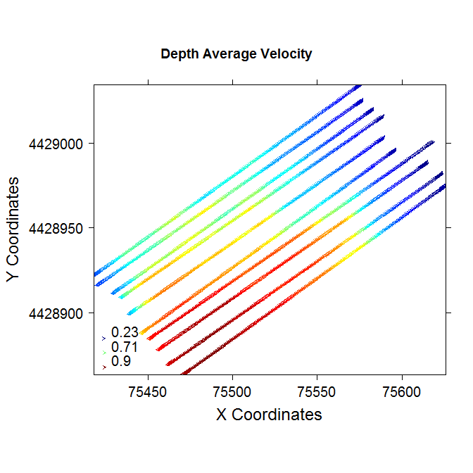

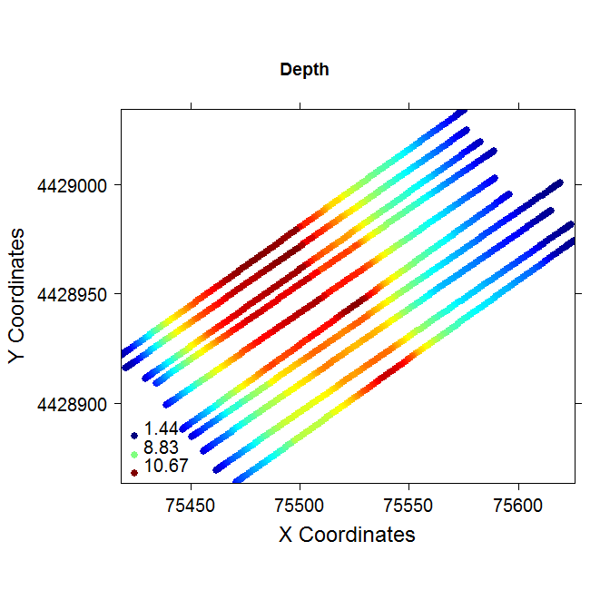

```r
plot.planform(planform.ADCP, DepthAveragedSpeed, main="Depth Average Velocity")
plot.planform(planform.ADCP, depth, arrows=FALSE, main="Depth")
```

The arrows in the plot above are small and displayed closely together. These arrows can be made larger by adjusting the `arrow_scale` and spacing can be increased by increasing the `point.spacing` value. Additionally, units can be added to the axis scale with `xUnits`. If the key overlaps data points, it can be positioned by defining the x and y coordinates of the key with `arrow.key`. The x and y-axis labels can be defined with xlab and ylab and the y-axis tick labels can be rotated with `scales=list(y=list(rot=90))` to make more efficient use of space.

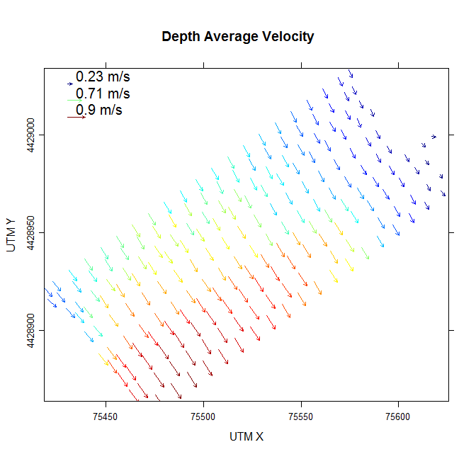

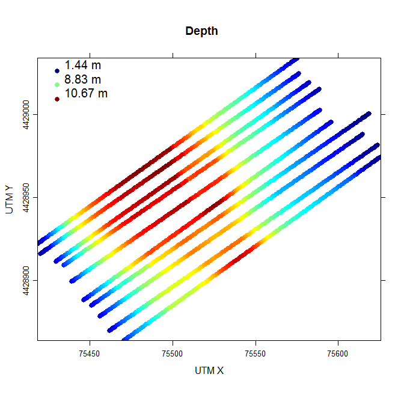

```r
plot.planform(planform.ADCP, DepthAveragedSpeed, point.spacing=10, arrow.key=c(75420,4429005),
              main="Depth Average Velocity", arrow_scale=10, xUnits="m/s", xlab="UTM X",
              ylab="UTM Y",  scales = list(y=list(rot=90)))
plot.planform(planform.ADCP, depth, arrows=FALSE, arrow.key=c(75420,4429005), main="Depth",
              xUnits="m", xlab="UTM X", ylab="UTM Y", scales=list(y=list(rot=90)))
```

`plot.planform` also has an option for displaying a parameter as an interpolated raster that is confined within the bounds of the sampled area. The default cell size is the x-axis range/100 by the y-axis range/100, but can be specified with the `cellWidth` and `cellHeight` arguments.

```r
plot.planform(planform.ADCP, interpolate=depth, main="Depth \nDefault Grid Cells", xlab="UTM X",
              ylab="UTM Y", ylab.right=list(label="Depth (m)", fontsize=18),
              scales=list(y=list(rot=90)))
```

```
## [inverse distance weighted interpolation]
```

```
## [inverse distance weighted interpolation]
```

[figure not shown]

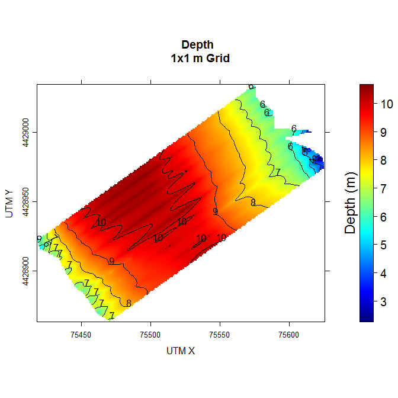

```r
plot.planform(planform.ADCP, interpolate=depth, cellWidth=1, cellHeight=1,
              main="Depth \n 1x1 m Grid", xlab="UTM X", ylab="UTM Y",
              ylab.right=list(label="Depth (m)", fontsize=18),
              scales=list(y=list(rot=90)))
```

Additionally, an interpolated raster can be overlaid by a plot of points or arrows displaying another parameter. The plot below displays depth averaged velocity over a depth raster. The arrow colors (`point.color`) have been set to black to for a clearer display. To reduce the amount of noise when overlaying plots, contour lines can be disabled with `contour=FALSE`.

```
## [inverse distance weighted interpolation]
```

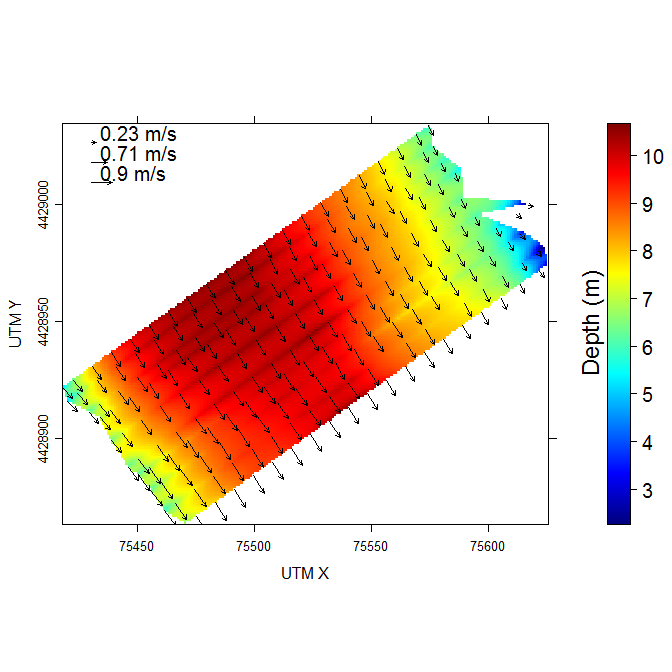

```r
plot.planform(planform.ADCP, DepthAveragedSpeed, depth, point.spacing=10,
              arrow.key=c(75420,4429005), point.color="black", arrow_scale=10,
              cellWidth=1, cellHeight=1, xUnits="m/s", contour=FALSE,
              ylab.right=list(label="Depth (m)", fontsize=18), xlab="UTM X", ylab="UTM Y",
              scales=list(y=list(rot=90)))
```

### Plot cross-section velocities

Plots of cross-section velocities are available through `plot.xSec`. `plot.xSec` accepts a dataset (`data`) and a parameter to plot (`x`), inverse distance weighting is then used to interpolate the parameter to a grid of a defined cell width (`cellWidth`) and height (`cellHeight`). If `cellWidth` and `cellHeight` are omitted, the default is to use the mean cell width and height of each transect plotted. If only specific transects are to be plotted, they can be defined with `transects`, which accepts a character vector of transect names. If all measured transects are to be plotted, transects can be omitted and `plot.xSec` defaults to plotting all transects in the dataset. The `...` of `plot.xSec` is for additional arguments that are to be passed to `plot.xSec.default`, which is the function that develops the plots. While `plot.xSec.default` can only plot one transect at a time, `plot.xSec` allows multiple transects to be processed, by sub-setting the dataset by transect and iteratively passing the data associated with each transect to `plot.xSec.default`.

Here the zero secondary discharge primary and secondary velocities are plotted. Note that only the primary velocity is supplied to `plot.xSec`, if a primary velocity (“vx”, “vp.zsq”, “vp.roz”, “vpx.roz”, or “vsx.roz”) is supplied to the function and `arrows=TRUE` secondary velocities from the appropriate rotation method are plotted with arrows. If `x` is not “vx”, “vp.zsq”, “vp.roz”, “vpx.roz”, or “vsx.roz” and `arrows=TRUE`, an error will be produced, setting `arrows=FALSE` allows the figure to be plotted.

```
## Cell Width: 1
```

```
## Cell Height: 0.5
```

```
## Arrow X Spacing : 10
```

```
## Arrow Y Spacing : 0.53
```

```
## [inverse distance weighted interpolation]
## [inverse distance weighted interpolation]
## [inverse distance weighted interpolation]
```

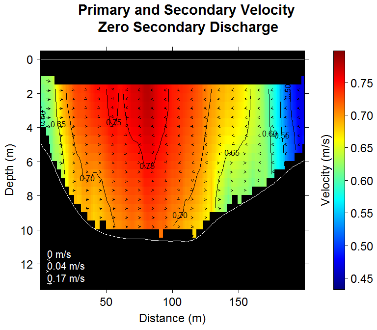

```r
plot.xSec(secondary.ADCP, vp.zsq, "t3",
          header="Primary and Secondary Velocity \nZero Secondary Discharge")
```

```
## Cell Width: 1
```

```
## Cell Height: 0.5
```

```
## Arrow X Spacing : 10
```

```
## Arrow Y Spacing : 0.53
```

```
## [inverse distance weighted interpolation]
```

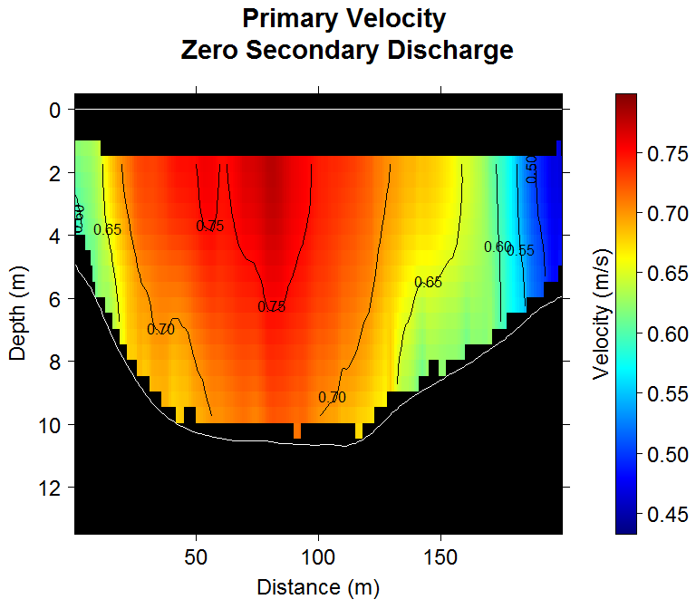

```r
plot.xSec(secondary.ADCP, vp.zsq, "t3", arrows=FALSE,
          header="Primary Velocity \nZero Secondary Discharge")
```

```
## Cell Width: 1
```

```
## Cell Height: 0.5
```

```
## Arrow X Spacing : 10
```

```
## Arrow Y Spacing : 0.53
```

```
## [inverse distance weighted interpolation]
```

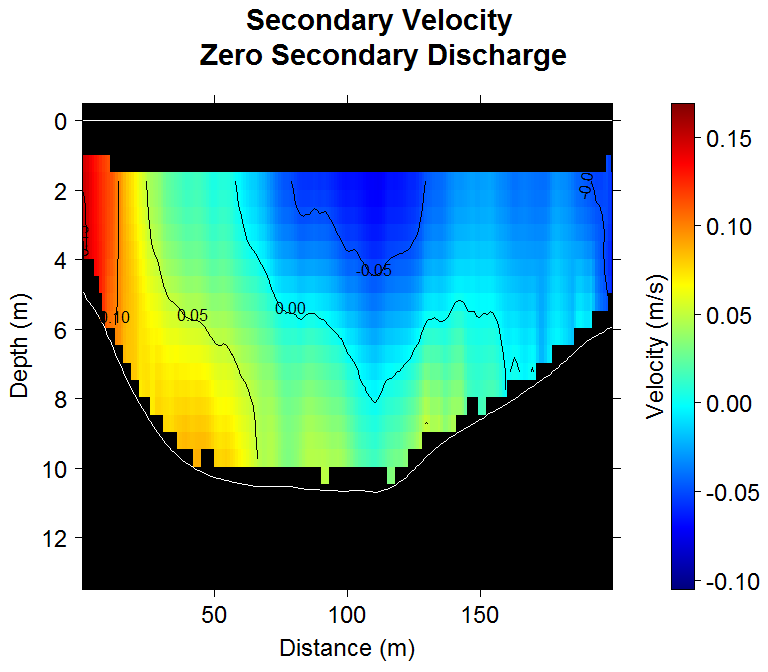

```r
plot.xSec(secondary.ADCP, vs.zsq,"t3", arrows=FALSE,
          header="Secondary Velocity \nZero Secondary Discharge")
```

Some other settings worth discussion are the arrow spacing, plot colors, and scale. The x and y spacing to the arrows defaults to 1/20th the transect distance and depth, respectively, arrow spacing can be adjusted with `arrow.x.spacing` and `arrow.y.spacing`. The default colors used are `jet.colors`, however the color scheme can be changed with `col.regions`, by setting it to another color ramp (e.g., heat.colors or terrain.colors). `black.white` and `white.black` are two notable color schemes that allow the plots to be produced in black and white, which allow the color scale to be preserved in second generation copies. `scale.by` allows users to plot transects that are scaled to the range of the parameter within the transect (`scale.by="individual"`) or to the range of the parameter within the dataset (`scale.by="all"`). Setting `scale.by=individual` allows a greater contrast within individual plots, however, `scale.by="all"` allows for easier comparison when multiple transects are plotted. Similar to `planform.plot`, `arrow_scale` controls the length of secondary flow arrows, arrow width can be increased by increasing `arrowwd`, and `arrowCol` controls arrow color.

The plots below show the transects scaled equally.

```
## Cell Width: 1
```

```
## Cell Height: 0.5
```

```
## Arrow X Spacing : 9.85
```

```
## Arrow Y Spacing : 0.53
```

```
## [inverse distance weighted interpolation]
## [inverse distance weighted interpolation]
## [inverse distance weighted interpolation]
```

```
## Cell Width: 1
```

```
## Cell Height: 0.49
```

```
## Arrow X Spacing : 10.15
```

```
## Arrow Y Spacing : 0.54
```

```
## [inverse distance weighted interpolation]
## [inverse distance weighted interpolation]
## [inverse distance weighted interpolation]
```

```
## Cell Width: 1
```

```
## Cell Height: 0.5
```

```
## Arrow X Spacing : 10
```

```
## Arrow Y Spacing : 0.53
```

```
## [inverse distance weighted interpolation]
## [inverse distance weighted interpolation]
## [inverse distance weighted interpolation]
```

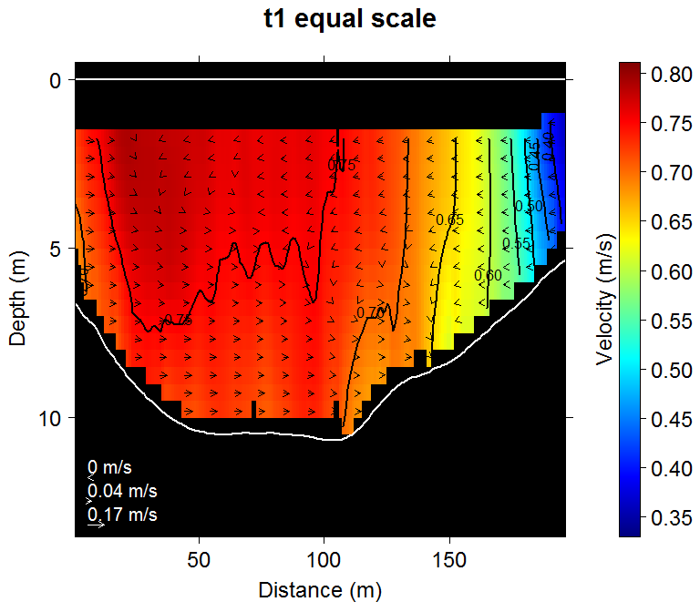

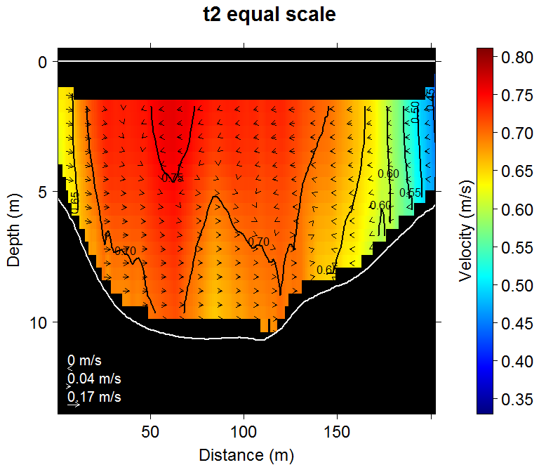

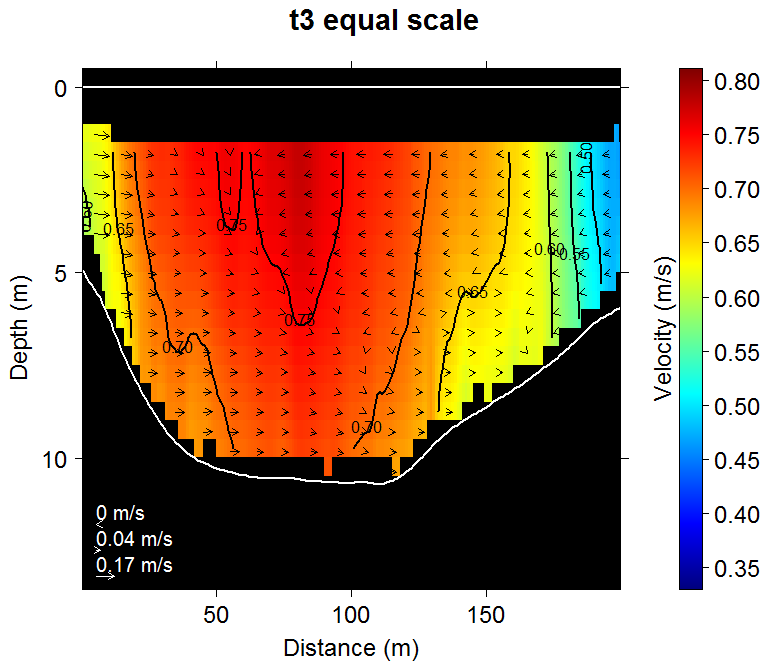

```r
plot.xSec(secondary.ADCP, vp.zsq, scale.by="all", arrow_scale=2, arrowwd=1.5, lwd=2,
          header=paste(transects[i], "equal scale"))
```

And the transects scaled individually.

```
## Cell Width: 1
```

```
## Cell Height: 0.5
```

```
## Arrow X Spacing : 9.85
```

```
## Arrow Y Spacing : 0.53
```

```
## [inverse distance weighted interpolation]
## [inverse distance weighted interpolation]
## [inverse distance weighted interpolation]
```

```
## Cell Width: 1
```

```
## Cell Height: 0.49
```

```
## Arrow X Spacing : 10.15
```

```
## Arrow Y Spacing : 0.54
```

```
## [inverse distance weighted interpolation]
## [inverse distance weighted interpolation]
## [inverse distance weighted interpolation]
```

```
## Cell Width: 1
```

```
## Cell Height: 0.5
```

```
## Arrow X Spacing : 10
```

```
## Arrow Y Spacing : 0.53
```

```
## [inverse distance weighted interpolation]
## [inverse distance weighted interpolation]
## [inverse distance weighted interpolation]
```

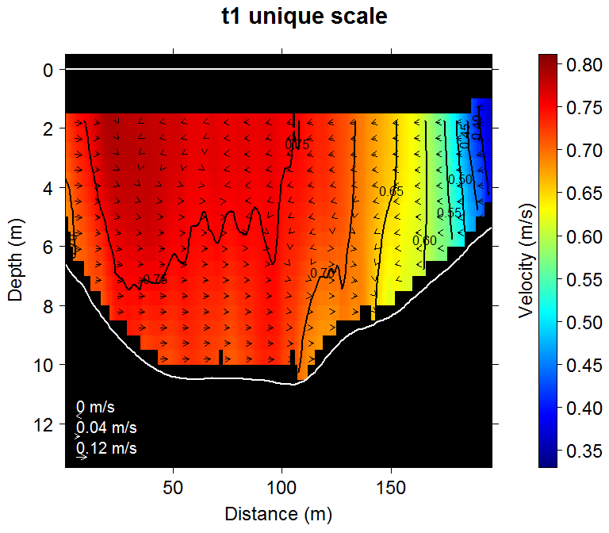

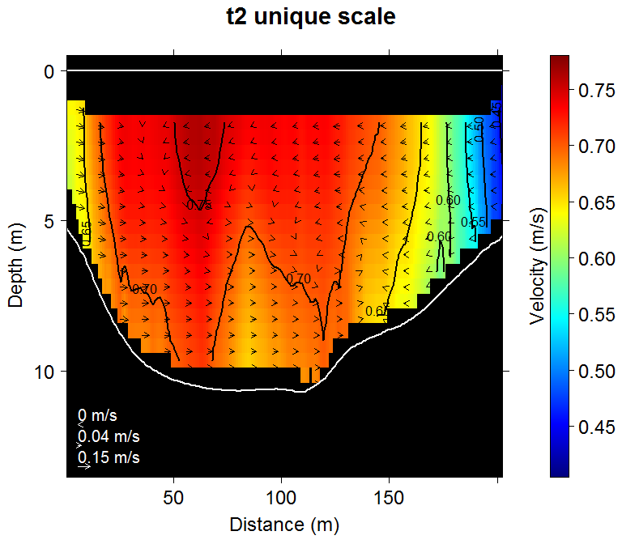

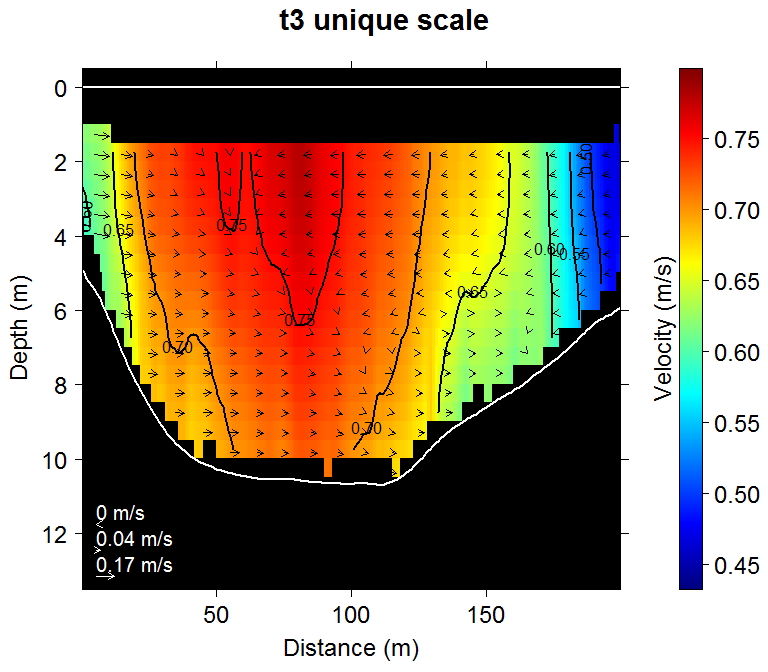

```r
plot.xSec(secondary.ADCP, vp.zsq, scale.by="individual", arrow_scale=2, arrowwd=1.5, lwd=2,
          header=paste(transects[i], "unique scale"))
```

As with `planform.plot`, contours can be disabled by setting `contour=FALSE`. This can help reduce the amount of noise on the plot. Below are the three rotation methods without contours displayed.

```
## Cell Width: 1
```

```
## Cell Height: 0.5
```

```
## Arrow X Spacing : 10
```

```
## Arrow Y Spacing : 0.53
```

```
## [inverse distance weighted interpolation]
## [inverse distance weighted interpolation]
## [inverse distance weighted interpolation]
```

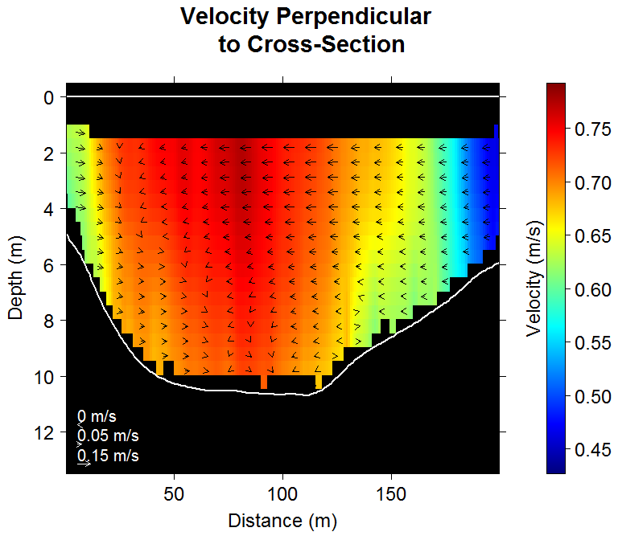

```r
plot.xSec(secondary.ADCP, vx, "t3", header="Velocity Perpendicular \n to Cross-Section",
          arrow_scale=2,arrowwd=1.5, lwd=2, contour=FALSE)
```

```
## Cell Width: 1
```

```
## Cell Height: 0.5
```

```
## Arrow X Spacing : 10
```

```
## Arrow Y Spacing : 0.53
```

```
## [inverse distance weighted interpolation]
## [inverse distance weighted interpolation]
## [inverse distance weighted interpolation]
```

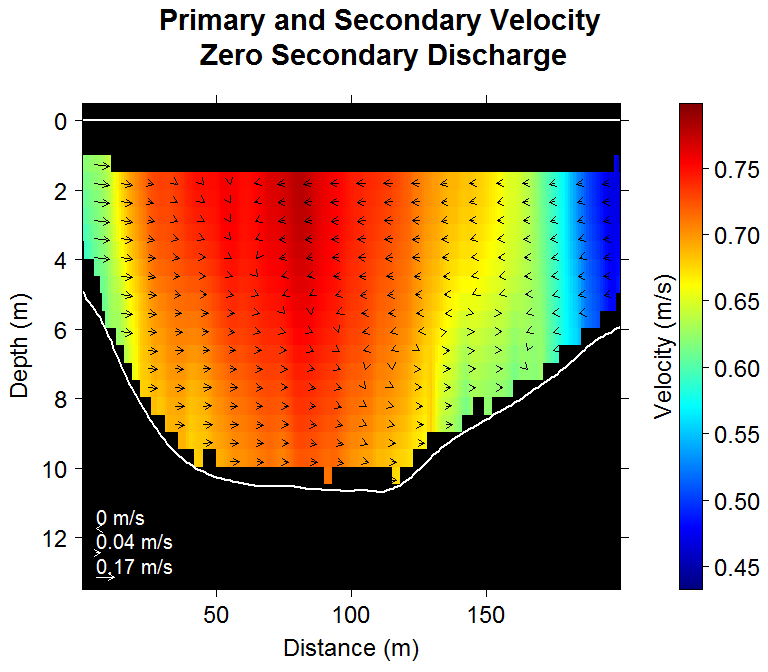

```r
plot.xSec(secondary.ADCP, vp.zsq, "t3",
          header="Primary and Secondary Velocity \nZero Secondary Discharge",
          arrow_scale=2, arrowwd=1.5, lwd=2, contour=FALSE)
```

```
## Cell Width: 1
```

```
## Cell Height: 0.5
```

```
## Arrow X Spacing : 10
```

```
## Arrow Y Spacing : 0.53
```

```
## [inverse distance weighted interpolation]
## [inverse distance weighted interpolation]
## [inverse distance weighted interpolation]
```

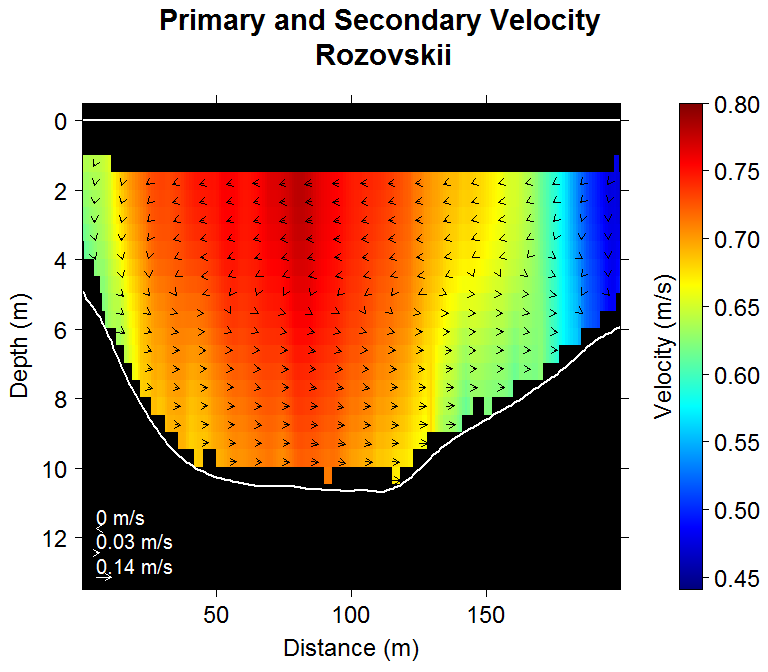

```r
plot.xSec(secondary.ADCP, vp.roz,"t3", header="Primary and Secondary Velocity \nRozovskii",
          arrow_scale=2, arrowwd=1.5, lwd=2, contour=FALSE)
```

Below is an example plot produced in black and white for publication.

```
## Cell Width: 1
```

```
## Cell Height: 0.5
```

```
## Arrow X Spacing : 10
```

```
## Arrow Y Spacing : 0.53
```

```
## [inverse distance weighted interpolation]
## [inverse distance weighted interpolation]
## [inverse distance weighted interpolation]
```

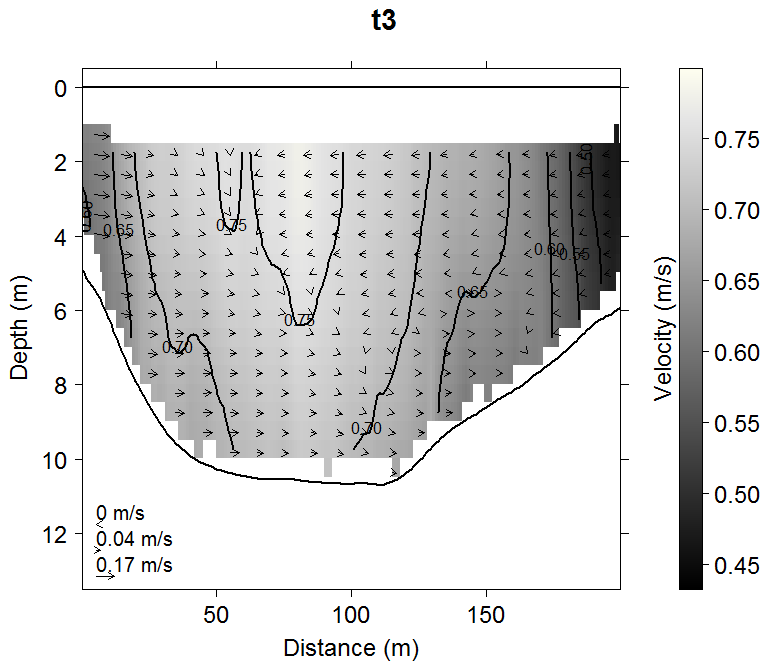

```r
plot.xSec(secondary.ADCP, vp.zsq, transects="t3", scale.by="individual", arrow_scale=2,
          arrowwd=1.5, lwd=2, lineCol="black", col.regions=black.white,
          keyCol="black", par.settings=list(layout.widths=list(axis.key.padding=0,
                                                               ylab.right=2),
                                            panel.background=list(col="white")))
```